# ProsperLoan Data Analysis

## Univariate Exploration

```python
def plot_pie(df, col):
    plt.pie(loan_df[col].value_counts(), autopct='%.2f%%');
    plt.title(f'Proportion of {col}', fontsize=14)
    plt.legend(loan_df[col].value_counts().index, loc = 'upper right');

def plot_count(df, col, base_color=None, rotation=0, order=None, hue=None, palette=None, title=''):
        sns.countplot(data=df,x= col, color=base_color, order=order, hue=hue, palette=palette)
        plt.title(f'{title}')
        plt.xlabel(f'{col}')
        plt.ylabel('Count')
        plt.xticks(rotation=rotation);
```

### Categorical features

```python
base_color = sns.color_palette()[0]
plt.rcParams["figure.figsize"] = (10, 8)
```

```python
loan_df['LoanStatus'].value_counts(normalize=True)
```

```
Completed     0.756040
Chargedoff    0.205294
Defaulted     0.038666
Name: LoanStatus, dtype: float64
```

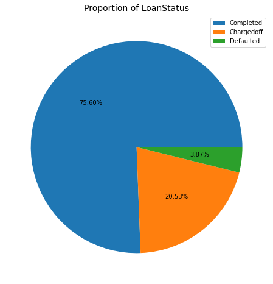

```python
plot_pie(loan_df, col='LoanStatus')
```

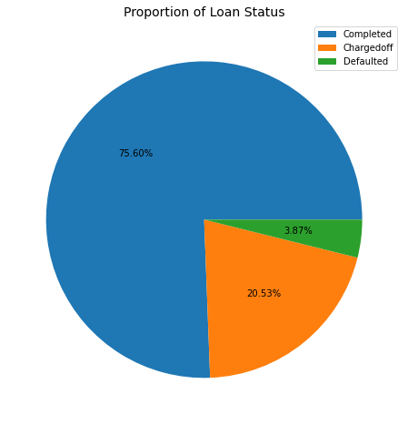

```python
plt.pie(loan_df['LoanStatus'].value_counts(), autopct='%.2f%%');
plt.title('Proportion of Loan Status', fontsize=14)
plt.legend(loan_df['LoanStatus'].value_counts().index, loc = 'upper right');
```

```python
loan_df['IsBorrowerHomeowner'].value_counts()
```

```
True     13255
False    12737
Name: IsBorrowerHomeowner, dtype: int64
```

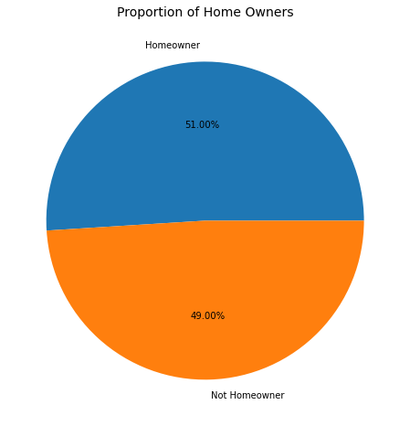

```python
plt.pie(loan_df['IsBorrowerHomeowner'].value_counts(), labels=['Homeowner', 'Not Homeowner'], autopct='%.2f%%')
plt.title('Proportion of Home Owners', fontsize=14);
```

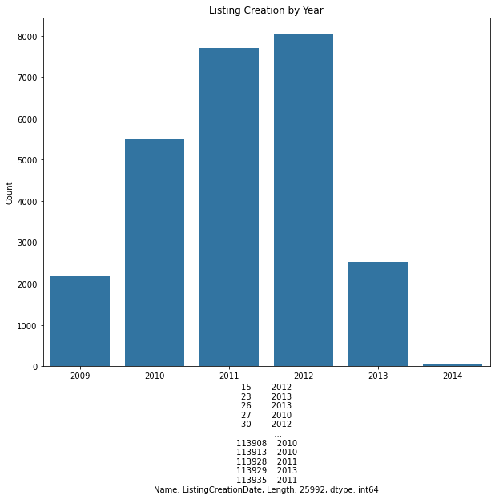

```python
# Listing Creation  by Year
plot_count(df=loan_df, col=loan_df['ListingCreationDate'].dt.year, base_color=base_color, title='Listing Creation by Year')
```

```python
loan_df.Term.value_counts()
```

```
36    20765
60    3696
12    1531
Name: Term, dtype: int64
```

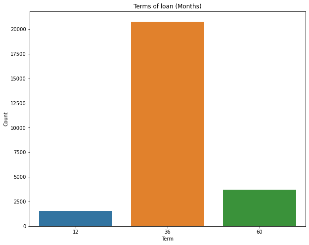

```python
plot_count(df=loan_df, col='Term', title='Terms of loan (Months)')
```

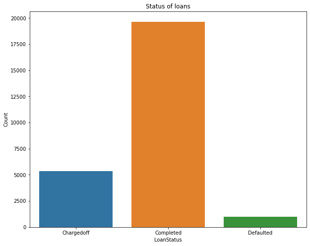

```python
plot_count(df=loan_df, col='LoanStatus', title='Status of loans')
```

```python
loan_df['BorrowerState'].value_counts().head(10)
```

```
CA    3305
FL    1762
NY    1629
TX    1543
IL    1381
GA    1122
OH    984
VA    918
NC    842
PA    804
Name: BorrowerState, dtype: int64
```

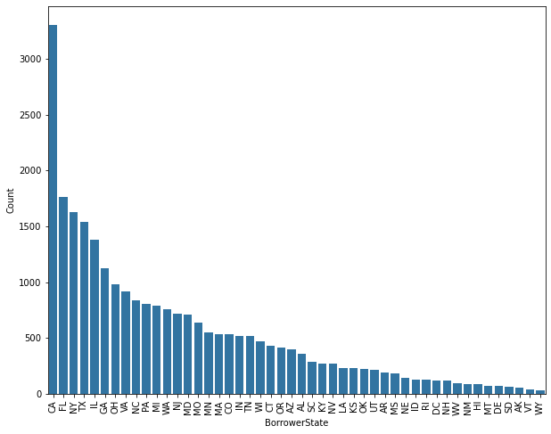

```python
#Borrower State Distrobution
cat_order = loan_df['BorrowerState'].value_counts().index
plot_count(df=loan_df, col='BorrowerState', base_color=base_color, order=cat_order, rotation=90)
```

```python
loan_df['ProsperRating_Alpha'].value_counts()
```

```
D      5867
E      3826
C      3815
HR     3722
A      3608
B      3371
AA     1783
N/A    0
Name: ProsperRating_Alpha, dtype: int64
```

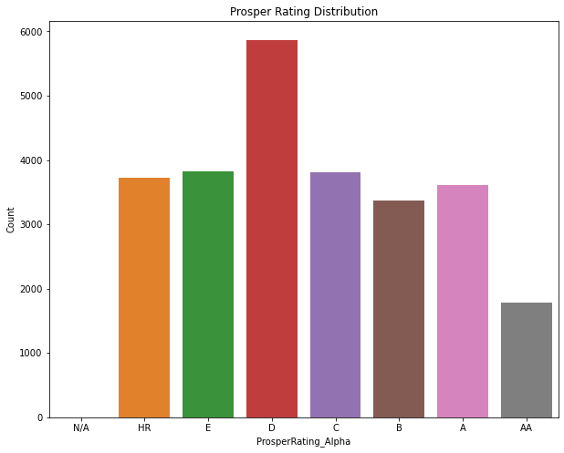

```python
# Prosper Rating
plot_count(df=loan_df, col='ProsperRating_Alpha', title='Prosper Rating Distribution')
```

```python
loan_df['IncomeRange'].value_counts()
```

```
$25,000-49,999    8319
$50,000-74,999    7362
$75,000-99,999    4024
$100,000+         3932
$1-24,999         1950
$0                30
Name: IncomeRange, dtype: int64
```

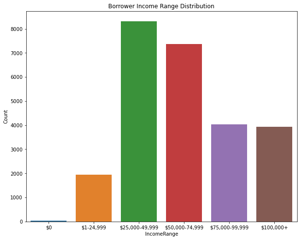

```python
#Borrower Income Range Status
plot_count(df=loan_df, col='IncomeRange', title='Borrower Income Range Distribution')
```

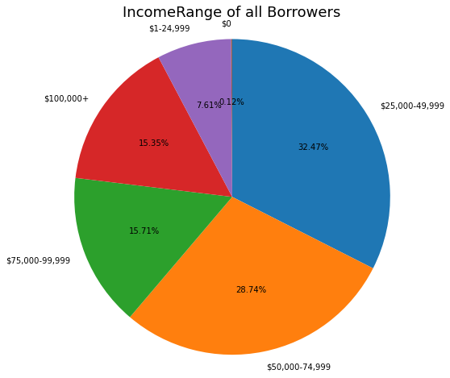

```python
sorted_counts = loan_df['IncomeRange'].value_counts()
plt.pie(sorted_counts, labels = sorted_counts.index, startangle = 90,
        counterclock = False, autopct   = '%.2f%%')
plt.title("IncomeRange of all Borrowers", fontsize=18)
plt.axis('square');
```

**ListingCategory:** (Nominal Variable)

- The category of the listing that the borrower selected when posting their listing:

  0 - Not Available

  1 - Debt Consolidation

  2 - Home Improvement

  3 - Business

  4 - Personal Loan

  5 - Student Use

  6 - Auto

  7- Other

  8 - Baby&Adoption

  9 - Boat

  10 - Cosmetic Procedure

  11 - Engagement Ring

  12 - Green Loans

  13 - Household Expenses

  14 - Large Purchases

  15 - Medical/Dental

  16 - Motorcycle

  17 - RV

  18 - Taxes

  19 - Vacation

  20 - Wedding Loans

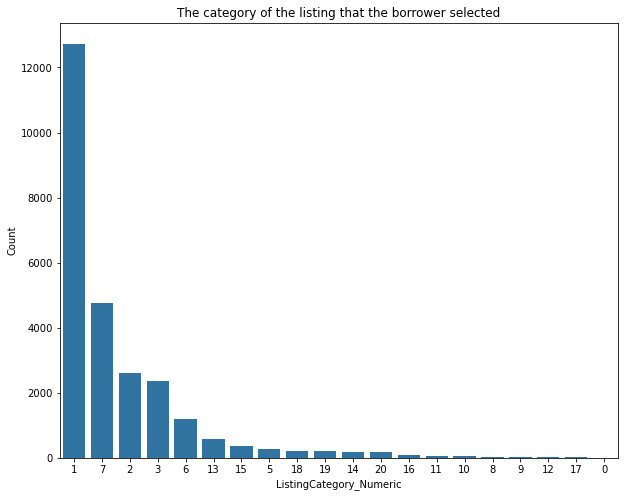

```python
# ListingCategory_Numeric
cat_order = loan_df['ListingCategory_Numeric'].value_counts().index
plot_count(df=loan_df, col='ListingCategory_Numeric', base_color=base_color, order=cat_order, title='The category of the listing that the borrower selected')
```

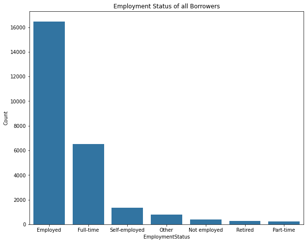

```python
# 'EmploymentStatus
cat_order = loan_df['EmploymentStatus'].value_counts().index
plot_count(df=loan_df, col='EmploymentStatus', base_color=base_color, order=cat_order, title='Employment Status of all Borrowers')
```

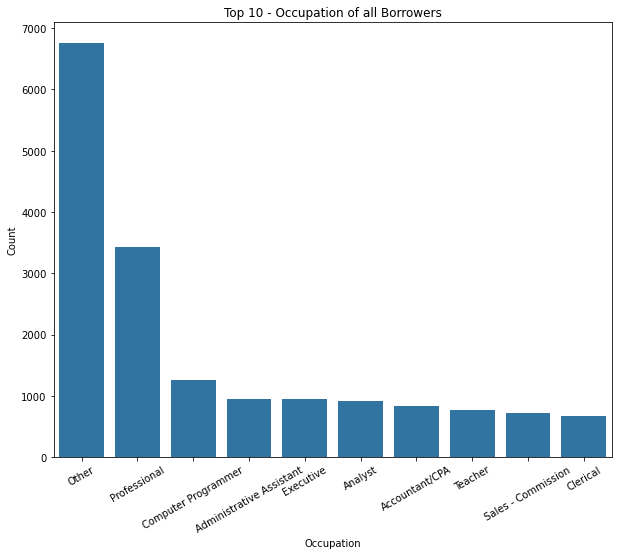

```python
# 'EmploymentStatus
cat_order = loan_df['Occupation'].value_counts().head(10).index
plot_count(df=loan_df, col='Occupation', base_color=base_color, order=cat_order, title='Top 10 - Occupation of all Borrowers', rotation=30)
```

### Insights from categorical features analysis

- Loans with a category of **"D"** had the greatest number.
- The majority of the loans were for terms of **36** months.
- The Top 2 years for Listing creation count are **2011, and 2012**
- The top 2 loan consideration reasons are **1 - Debt Consolidation, 7 - Other**
- LoanStatus of all Borrowers are with **Chargedoff**, **Completed** and **Defaulted** state
- The majority of borrowers have an EmploymentStatus of "Employed," then "Full-time,"
- The top income bracket for all borrowers is between $25,000 and $49,999.
- The top two borrowing jurisdictions are **CA** and **FL**.
- The majority of borrowers work in **Other** and **Professional** fields.

### Numerical features

```
     'ProsperScore', 'ProsperRating_Numeric', 'BorrowerAPR', 'BorrowerRate', 'StatedMonthlyIncome', 'MonthlyLoanPayment', 'LoanOriginalAmount', 'Investors'
```

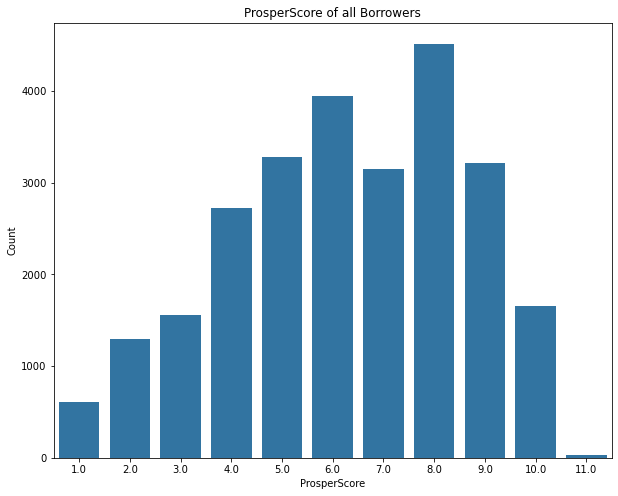

```python
#'ProsperScore'
plot_count(df=loan_df, col='ProsperScore', base_color=base_color, title='ProsperScore of all Borrowers')
```

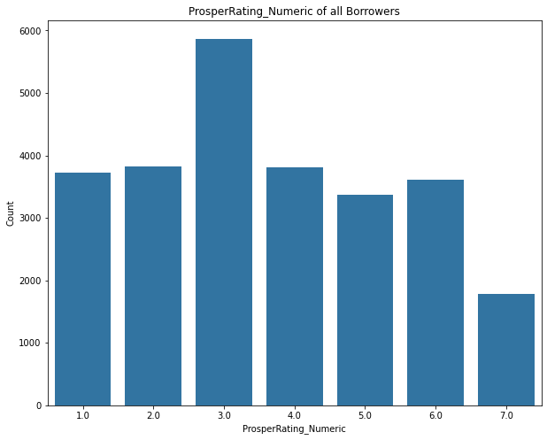

```python
# 'ProsperRating_Numeric'
plot_count(df=loan_df, col='ProsperRating_Numeric', base_color=base_color, title='ProsperRating_Numeric of all Borrowers')
```

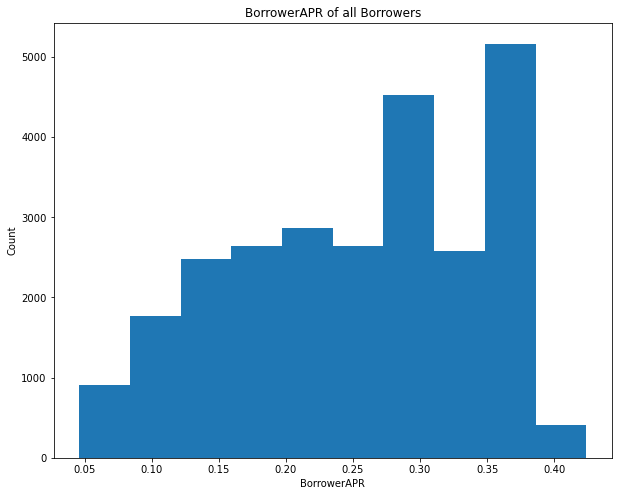

```python
# 'BorrowerAPR'
plt.hist(x = loan_df['BorrowerAPR'])
plt.xlabel('BorrowerAPR')
plt.ylabel('Count')
plt.title("BorrowerAPR of all Borrowers");
```

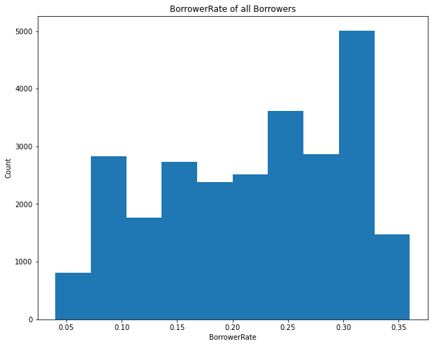

```python
# 'BorrowerRate'
plt.hist(data = loan_df, x = 'BorrowerRate')
plt.xlabel('BorrowerRate')
plt.ylabel('Count')
plt.title("BorrowerRate of all Borrowers");
```

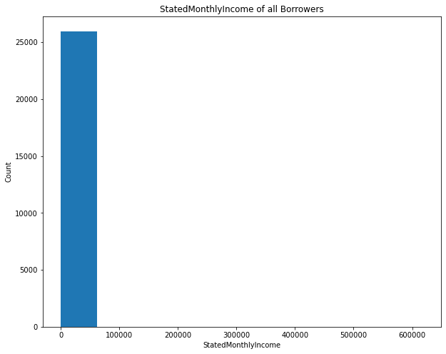

```python
plt.hist(data = loan_df, x = 'StatedMonthlyIncome')
plt.xlabel('StatedMonthlyIncome')
plt.ylabel('Count')
plt.title("StatedMonthlyIncome of all Borrowers");
```

```python
(loan_df['StatedMonthlyIncome'].describe())
```

```
count    25992.000000
mean     5491.003507
std      6825.602083
min      0.000000
25%      3166.666667
50%      4583.333333
75%      6666.666667
max      618547.833333
Name: StatedMonthlyIncome, dtype: float64
```

```python
np.log10(loan_df['StatedMonthlyIncome'].describe())
```

```
count    4.414840
mean     3.739652
std      3.834141
min     -inf
25%      3.500602
50%      3.661181
75%      3.823909
max      5.791373
Name: StatedMonthlyIncome, dtype: float64
```

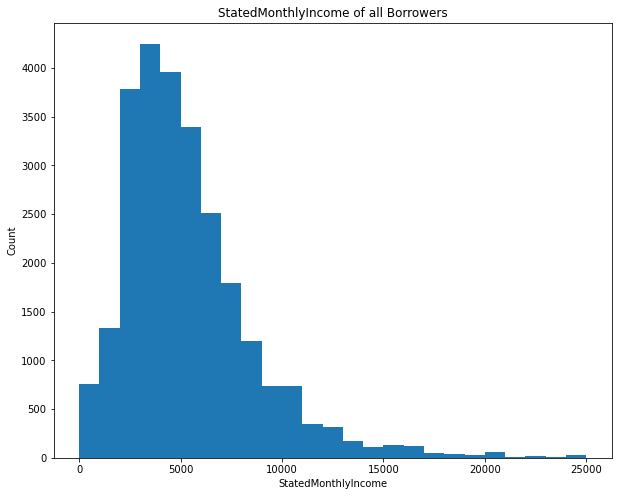

```python
loan_df_sub = loan_df[loan_df['StatedMonthlyIncome'] <= 25000]
bin_edges = np.arange(0, loan_df_sub['StatedMonthlyIncome'].max()+1000, 1000)
plt.hist(data = loan_df, x = 'StatedMonthlyIncome', bins = bin_edges)
plt.xlabel('StatedMonthlyIncome')
plt.ylabel('Count')
plt.title("StatedMonthlyIncome of all Borrowers");
```

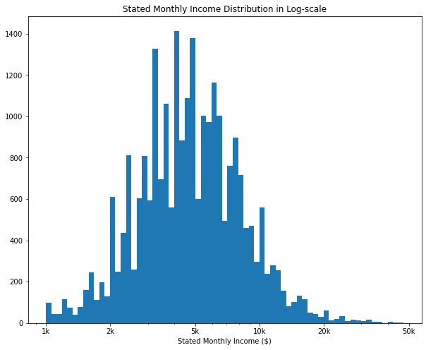

```python
# Using log-scale
#In addition, truncate the X axis to show only values less than 50k which are the majority of data
log_binsize = 0.025
bins = 10 ** np.arange(3, 4.7, log_binsize)

plt.hist(data = loan_df, x = 'StatedMonthlyIncome', bins = bins)
plt.xscale('log')
plt.xticks([1e3, 2e3, 5e3, 1e4, 2e4, 5e4], ['1k', '2k','5k', '10k', '20k', '50k'])
plt.xlabel('Stated Monthly Income ($)')
plt.title('Stated Monthly Income Distribution in Log-scale')
plt.show()
```

- It's interesting to note that the peak occurs around $5k

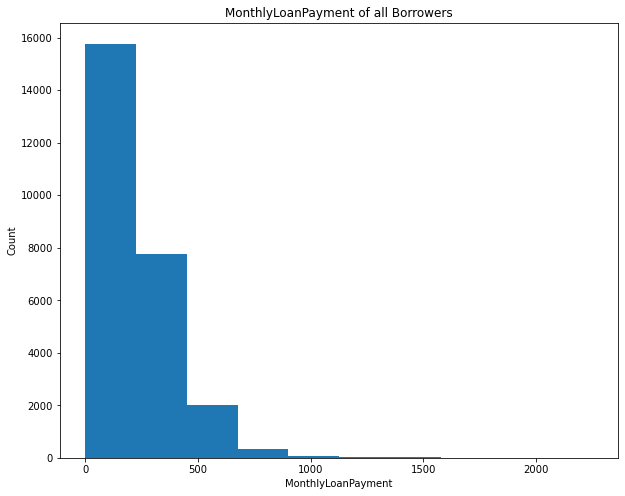

```python
# 'MonthlyLoanPayment'
plt.hist(data = loan_df, x = 'MonthlyLoanPayment')
plt.xlabel('MonthlyLoanPayment')
plt.ylabel('Count')
plt.title("MonthlyLoanPayment of all Borrowers");
```

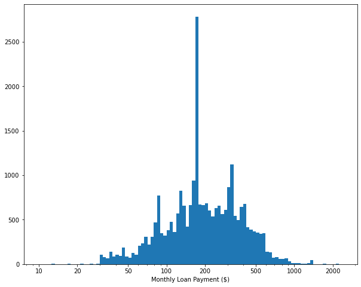

```python
# Using log-scale
log_binsize = 0.025
bins = 10 ** np.arange(1, np.log10(loan_df['MonthlyLoanPayment'].max())+log_binsize, log_binsize)

plt.hist(data = loan_df, x = 'MonthlyLoanPayment', bins = bins)
plt.xscale('log')
plt.xticks([10, 20, 50, 100, 200, 500, 1e3, 2e3], ['10', '20','50', '100', '200', '500', '1000', '2000'])
plt.xlabel('Monthly Loan Payment ($)')
plt.show()
```

- Observing the details of the price range below 500 USD and the peak between 100 USD and 200 USD is fascinating.

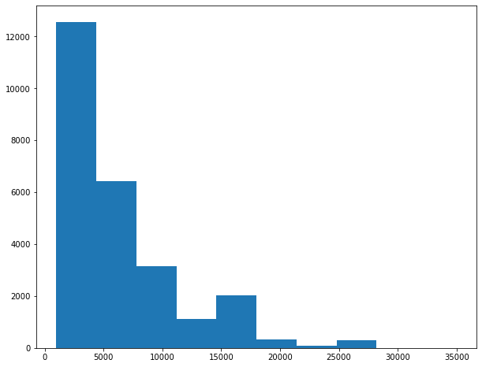

```python
plt.hist(data = loan_df, x = 'LoanOriginalAmount');
```

```python
(loan_df['LoanOriginalAmount'].describe())
```

```
count    25992.000000
mean     6375.824523
std      4781.752809
min      1000.000000
25%      3000.000000
50%      4500.000000
75%      8000.000000
max      35000.000000
Name: LoanOriginalAmount, dtype: float64
```

```python
np.log10(loan_df['LoanOriginalAmount'].describe())
```

```
count    4.414840
mean     3.804536
std      3.679587
min      3.000000
25%      3.477121
50%      3.653213
75%      3.903090
max      4.544068
Name: LoanOriginalAmount, dtype: float64
```

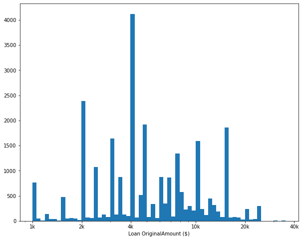

```python
# Using log-scale
log_binsize = 0.025
bins = 10 ** np.arange(3, np.log10(loan_df['LoanOriginalAmount'].max())+log_binsize, log_binsize)

plt.hist(data = loan_df, x = 'LoanOriginalAmount', bins = bins)
plt.xscale('log')
plt.xticks([1e3, 2e3, 4e3, 1e4, 2e4, 4e4], ['1k', '2k','4k', '10k', '20k', '40k'])
plt.xlabel('Loan OriginalAmount ($)')
plt.show()
```

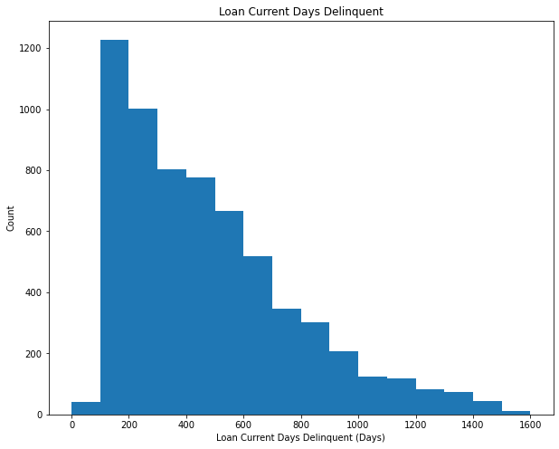

```python
# Loan Current Days Delinquent Distribution
binsize = 100
bins = np.arange(0, loan_df['LoanCurrentDaysDelinquent'].max()+binsize, binsize)

plt.hist(data = loan_df[loan_df['LoanCurrentDaysDelinquent']>0], x = 'LoanCurrentDaysDelinquent', bins = bins)
plt.title('Loan Current Days Delinquent')
plt.xlabel('Loan Current Days Delinquent (Days)')
plt.ylabel('Count')
plt.show()
```

```python
(loan_df['Investors'].describe())
```

```
count    25992.000000
mean     92.393429
std      97.980331
min      1.000000
25%      28.000000
50%      62.000000
75%      125.000000
max      1189.000000
Name: Investors, dtype: float64
```

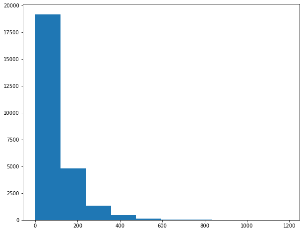

```python
plt.hist(data = loan_df, x = 'Investors');
```

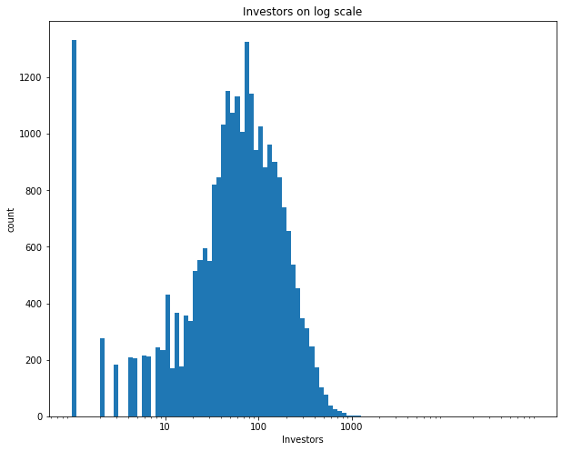

```python
#Number of Investors Distrobution on log scale for all loans
log_binsize = 0.05
bins = 10 ** np.arange(0, 5, log_binsize)

plt.hist(data = loan_df, x = 'Investors', bins = bins)
plt.title('Investors on log scale')
plt.xscale('log')
plt.xticks([1e1, 1e2, 1e3], ['10', '100', '1000'])
plt.xlabel('Investors')
plt.ylabel('count')
plt.show()
```